# 다음의 문제를 R Markdown 보고서(HTML 형식)로 제출하시오.

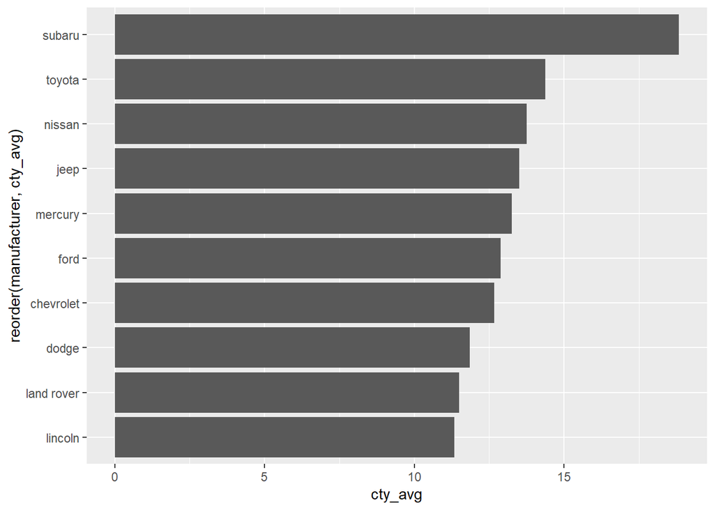

```r
suv_cty <- filter(mpg, class=='suv') %>%
      group_by(manufacturer) %>%
      summarise(cty_avg=mean(cty))
ggplot(suv_cty, aes(reorder(manufacturer,cty_avg),cty_avg)) +
      geom_bar(stat = 'identity') +
      coord_flip()
```

### 4. 자동차 중에서 어떤 class(자동차 종류)가 가장 많은지 알아보려고 합니다. 자동차 종류별 빈도를 표현한 막대 그래프를 만들어 보세요.

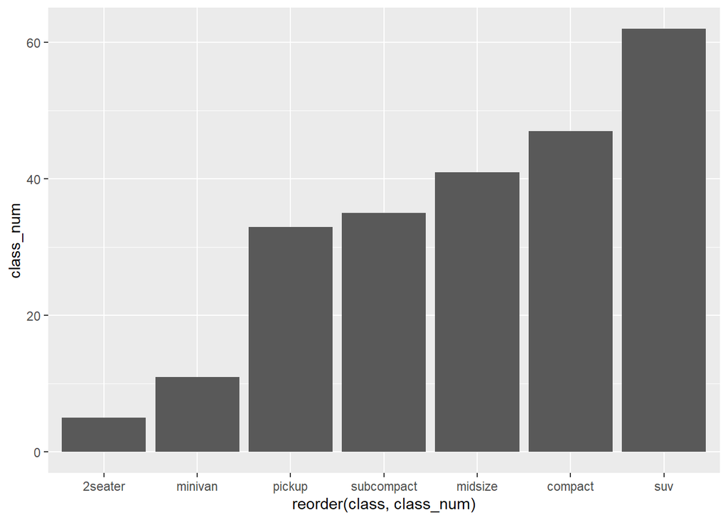

```r
mpg %>%
      group_by(class) %>%
      summarise(class_num=length(class)) %>%
      ggplot(aes(reorder(class,class_num),class_num)) +
      geom_bar(stat = 'identity')
```

### 5. economics 데이터를 이용해서 psavert(개인 저축률)가 시간에 따라서 어떻게 변해왔는지 알아보려고 합니다. 시간에 따른 개인 저축률의 변화를 나타낸 시계열 그래프를 만들어 보세요.

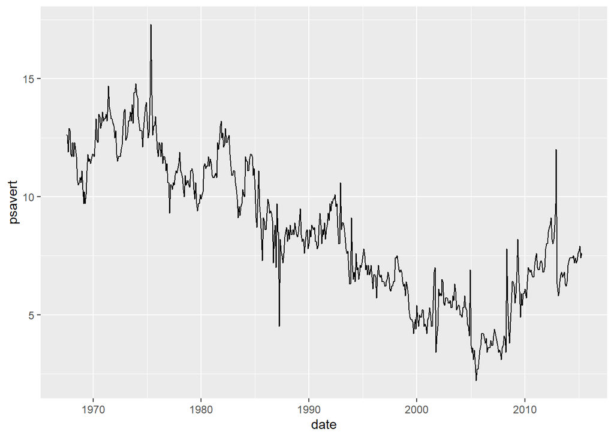

```r
ggplot(economics, aes(date, psavert)) +
      geom_line()
```

### 6. class(자동차 종류)가 “compact”, “subcompact”, “suv”인 자동차의 cty(도시 연비)가 어떻게 다른지 비교해보려고 합니다. 세 차종의 cty를 나타낸 상자 그림을 만들어보세요.

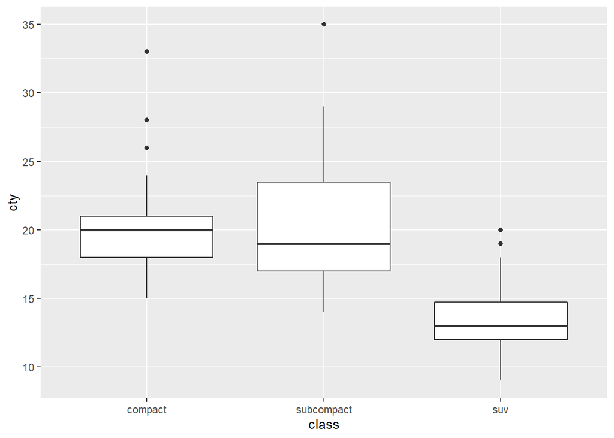

```r
mpg %>%
      filter(class %in% c('compact','subcompact','suv')) %>%
      ggplot(aes(class, cty)) +
      geom_boxplot()
```

### 7. Diamonds 데이터 셋을 이용하여 다음 문제를 해결하세요. 단, 컬러, 제목, x축, y축 등 그래프를 예쁘게 작성하세요.

#### 1) cut의 돗수를 보여주는 그래프를 작성하세요.

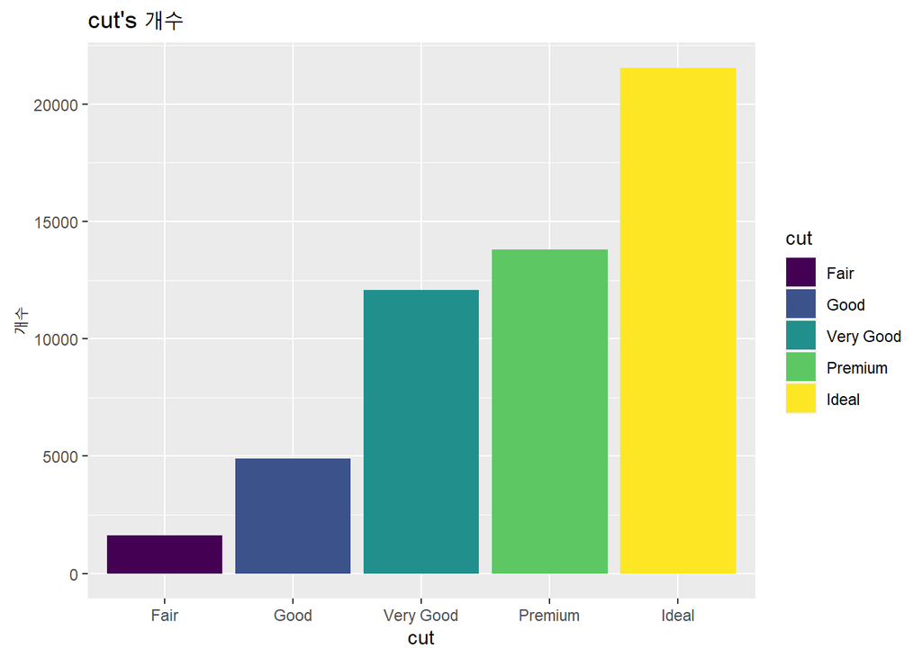

```r
diamonds %>%
      group_by(cut) %>%
      summarise(cut_num=length(cut)) %>%
      ggplot(aes(cut,cut_num)) +
      geom_bar(stat = 'identity',aes(fill=cut)) +
      labs(title = "cut's 개수", x= "cut",y="개수")
```

#### 2) cut에 따른 가격의 변화를 보여주는 그래프를 작성하세요.

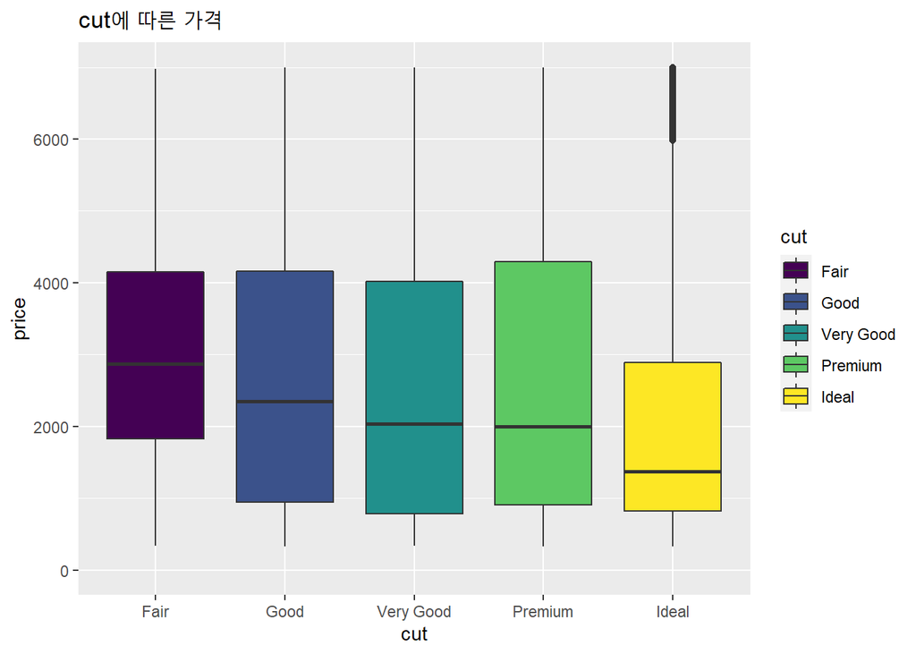

```r
diamonds %>%
      ggplot(aes(cut,price, fill = cut)) +
      geom_boxplot() +
      labs(title="cut에 따른 가격") +
      ylim(0,7000)
```

#### 3) cut과 color에 따른 가격의 변화를 보여주는 그래프를 작성하세요.

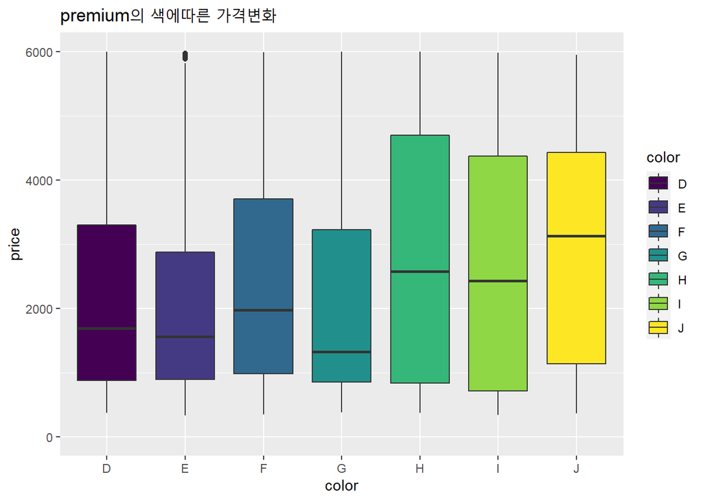

```r
cut_premium <- filter(diamonds, cut=='Premium')
cut_ideal <- filter(diamonds, cut=='Ideal')
cut_Verygood <- filter(diamonds, cut=='Very Good')
cut_good <- filter(diamonds, cut=='Good')
cut_fair <- filter(diamonds, cut=='Fair')
ggplot(cut_premium, aes(color,price,fill=color)) +
      geom_boxplot() +
      labs(title="premium의 색에따른 가격변화") +
      ylim(0,6000)
```

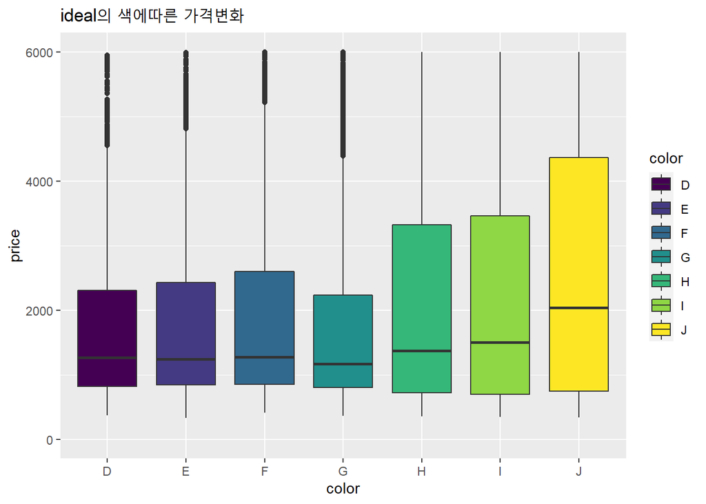

```r
ggplot(cut_ideal, aes(color,price,fill=color)) +
      geom_boxplot() +
      labs(title="ideal의 색에따른 가격변화") +
      ylim(0,6000)
```

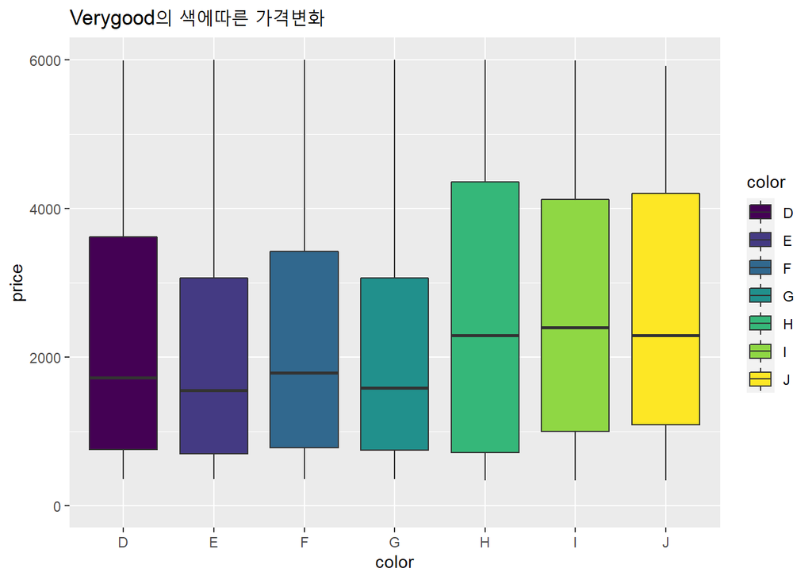

```r
ggplot(cut_Verygood, aes(color,price,fill=color)) +
      geom_boxplot() +
      labs(title="Verygood의 색에따른 가격변화") +
      ylim(0,6000)
```

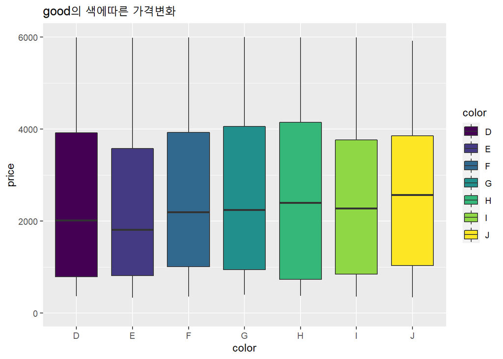

```r
ggplot(cut_good, aes(color,price,fill=color)) +
      geom_boxplot() +
      labs(title="good의 색에따른 가격변화") +
      ylim(0,6000)
```

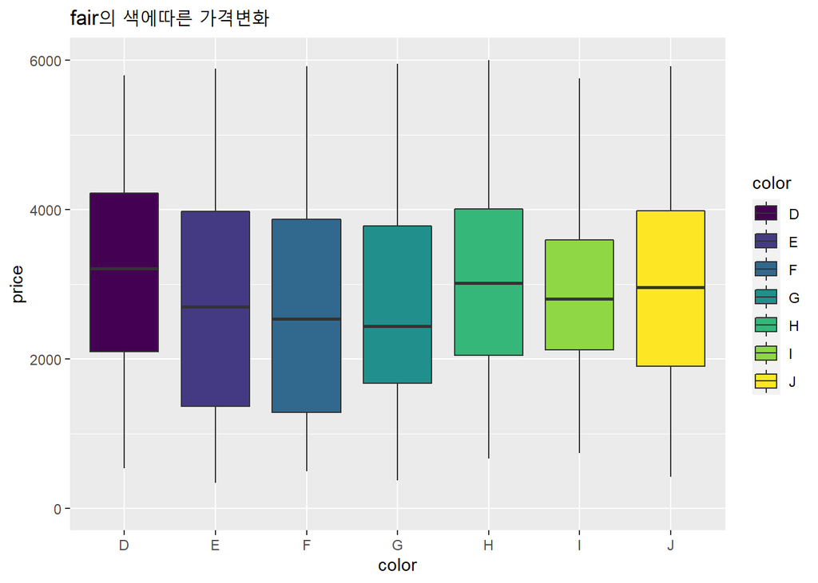

```r
ggplot(cut_fair, aes(color,price,fill=color)) +
      geom_boxplot() +
      labs(title="fair의 색에따른 가격변화") +
       ylim(0,6000)
```